# Text Prediction - Milestone Report

Chris Hammond

March 4, 2019

### Overview

This report contains exploratory analysis of the data provided to create a text prediction algorithm. Composite datasets from three sources were provided: news articles, twitter, and blog posts. An algorithm will be trained using the data to create a Shiny app.

### Data Summary

A basic summary of the three datasets can be seen in the table below.

```
##           Lines LinesNEmpty     Chars CharsNWhite WordCount WordAverage
## blogs    899288      899288 206824382   170389539  37546239    41.75107
## news    1010242     1010242 203223154   169860866  34762395    34.40997
## twitter 2360148     2360148 162096241   134082806  30093413    12.75065
```

### Data Visualization

A random sample was taken from each of the three datasets to illustrate major features of the data relevant to text prediciton. The sample data was then cleaned for better processing. The most common words in the combined data sample are shown in the graphic below. Larger words are more common.

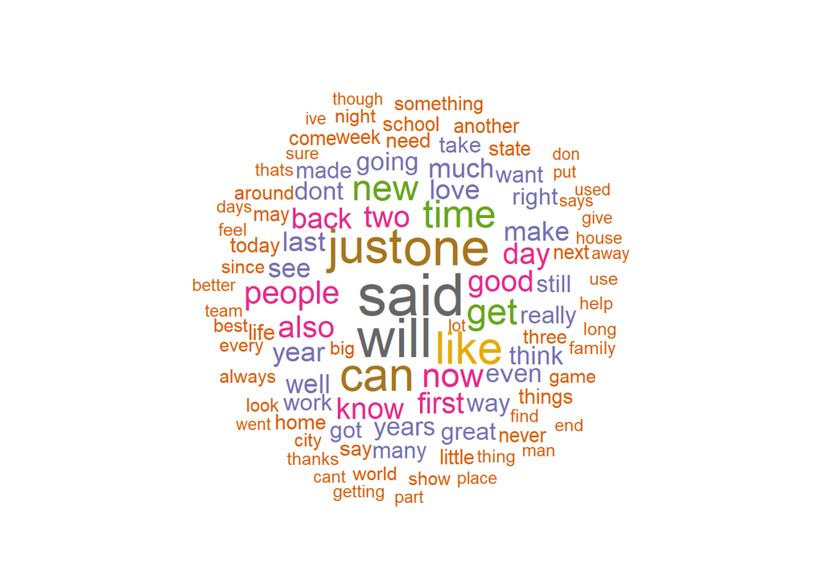

Next, N-gram tokenization is used to see what groups of words appear most frequently. The top fifty 2-grams and 3-grams are depicted in the graphs below.

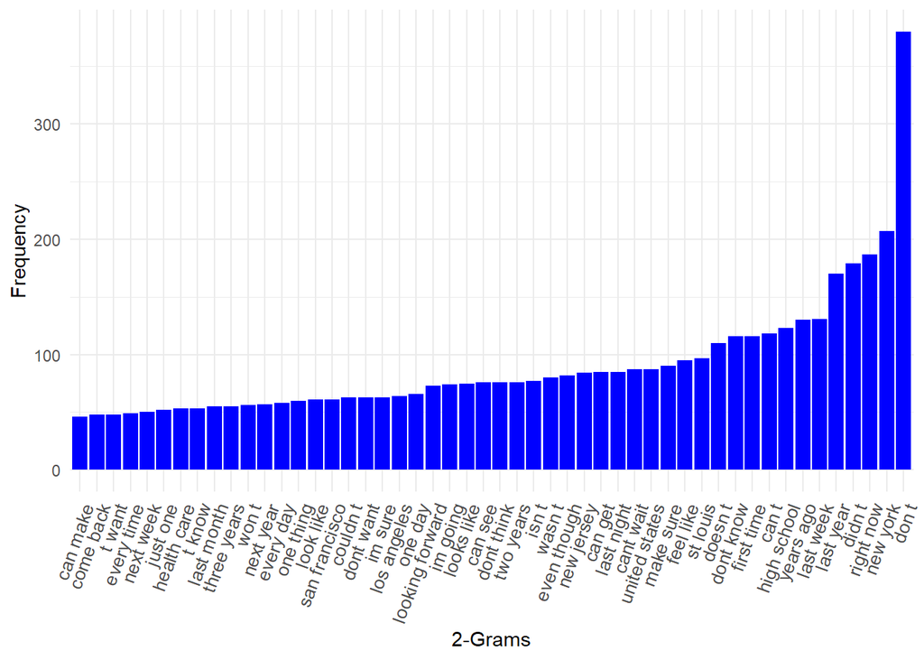

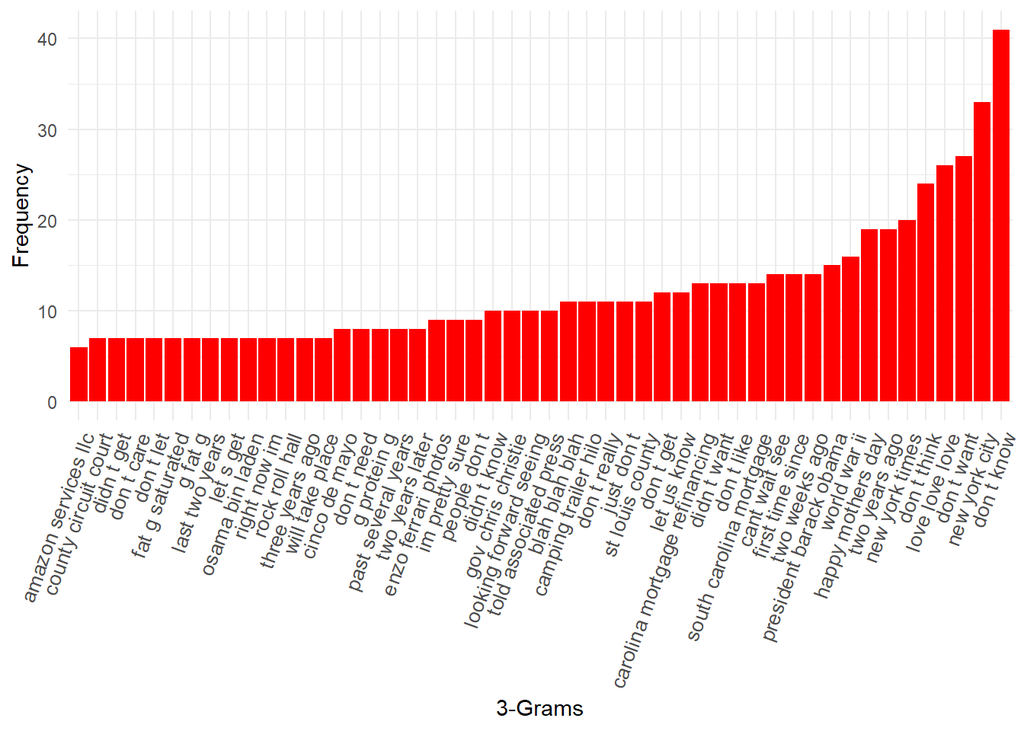

The above models produce many commonly used phrases. The word groupings appear less useful once the 3-gram threshold is crossed. The graph below shows the top twenty-five 4-grams.

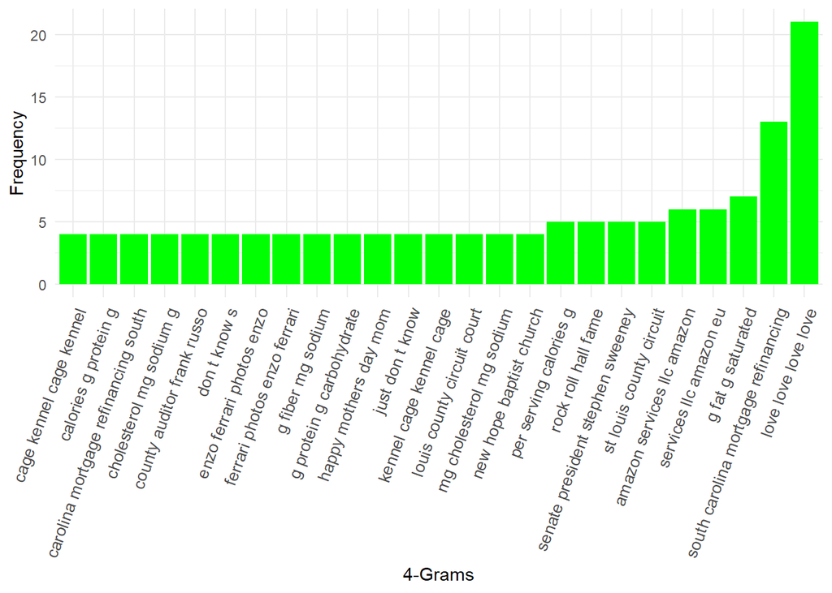

Higher numbers for tokenization were also investigated, but results on the sample were not promising. The graph below shows the top eight 5-grams.

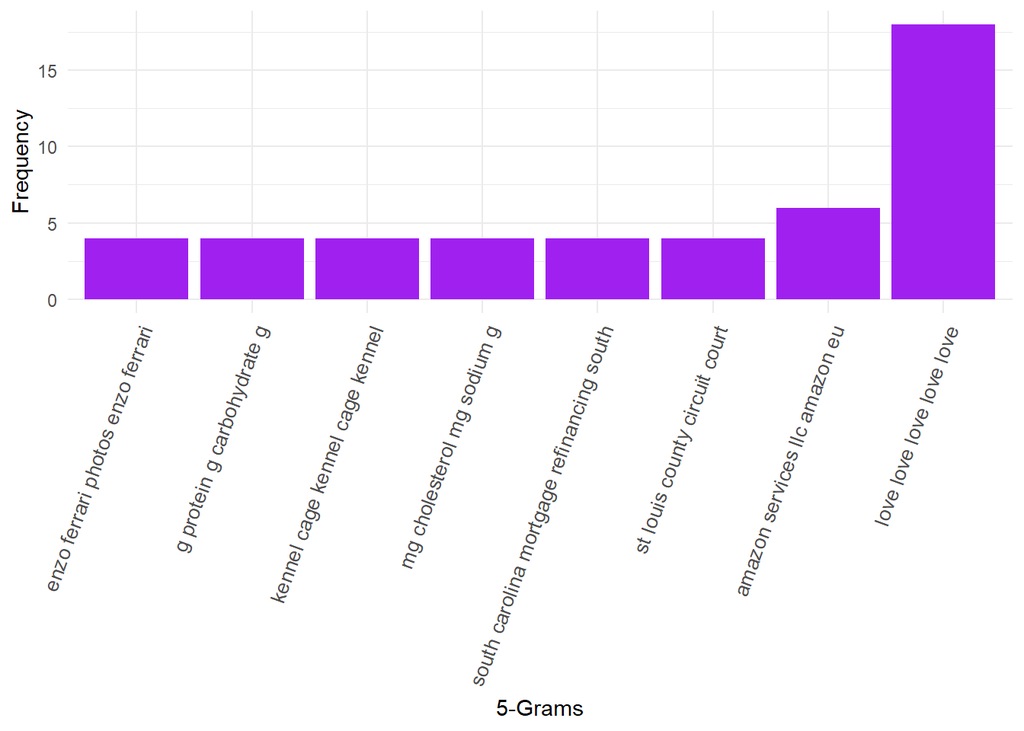

### Plans

The next step is to build an app that predicts the users next word based on the previous 1-3 words entered. I will focus on 2-gram and 3-gram models for prediction and utilize punctuation to improve data tokenization for more accurate results. The algorithm will be trained on a much larger sample of the data than the one used for this report.